# Landfills in Sub-Saharan Africa A Case Study of Ghana and Kenya

Author

Nykol Armacanqui Martinez de Tudor and Labanya Paul

## 2. The data set

## *Sources*

DHS Program – https://dhsprogram.com/, 16.05.2024.

DHS IPUMS – https://www.idhsdata.org/idhs/, 16.05.2024. “IPUMS-DHS” (n.d.)

Google Earth Pro – https://earth.google.com/intl/earth/versions/, 10.05.2024 “Earth Versions” (n.d.)

Variables -

• Wealth variable: ‘Household wealth index in quantiles’. This shows the households wealth in 5 equal parts (sample divided into 5 equal sized groups). This index is constructed using data from surveys. It consists of labels to depict wealth categories - 1: poorest, 2: poorer, 3: middle, 4: richer, and 5: richest. There is also 8: missing, and 9:NIU (not in universe) labels but these are not included after data wrangling (drop NA’s).

- Landfill variable: This is shown through the area size of the landfills throughout the years, in meters squared. For the landfill, city center buffers and rings in the wrangling phase, the original unit of measurement is in ‘Gold Coast Foot’ which represents the radius. This is a unit of measurement used in Ghana and is equivalent to 0.3048 meters. Kenya has also used this unit of measurement and CRS.

Sample period –

• We will examine the years 2008 and 2014 for the wealth variable. The total units of study consisted of 282,836 units, but after cleaning and wrangling; the units of study of Kenya at 4,762 households and Ghana at 7,232 households. For landfill data, we will use satellite imagery between the years 2008 to 2014.

The wealth data sample may be unreliable due to limited surveys and a short sample period. Landfill data accuracy may also be affected by image quality issues on Google Earth Pro.

## Summary statistics

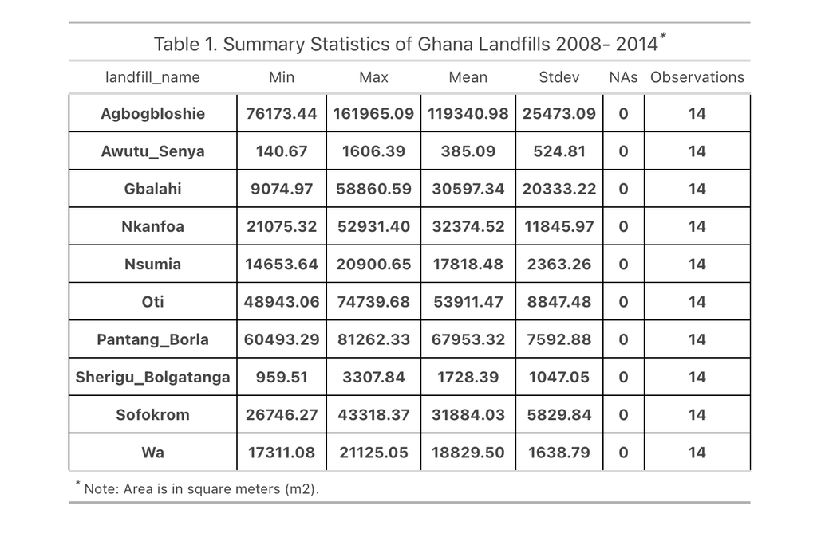

These were the summary statistics of all the landfills in Ghana, the main landfills used in the regression and analysis phase are Oti and Agbogbloshie.

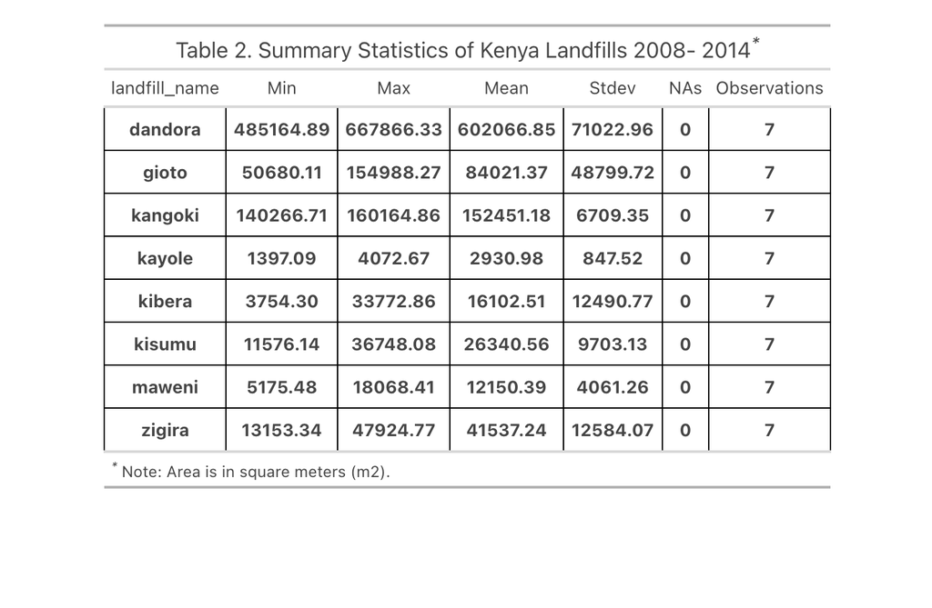

These were the summary statistics of all the landfills in Kenya, the main landfills studied were Dandora, Kibera and Maweni.

# Landfills

### Ghana

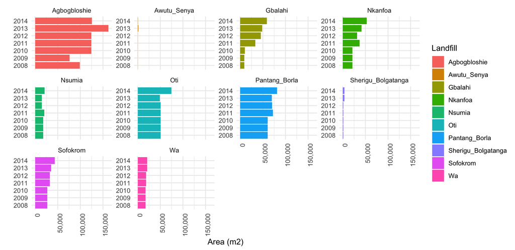

These show all the landfill areas derived from the Ghana polygons. The biggest landfill is Agbogbloshie located in the capital city of Accra.

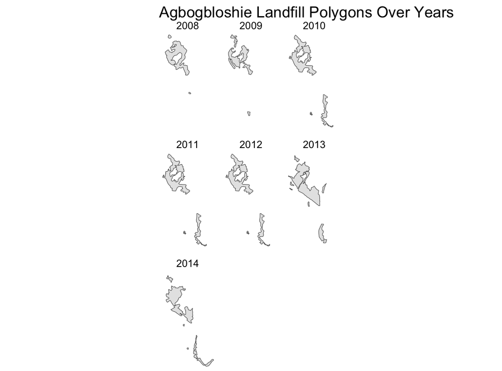

The change in Agbogbloshie landfill growth through the years.

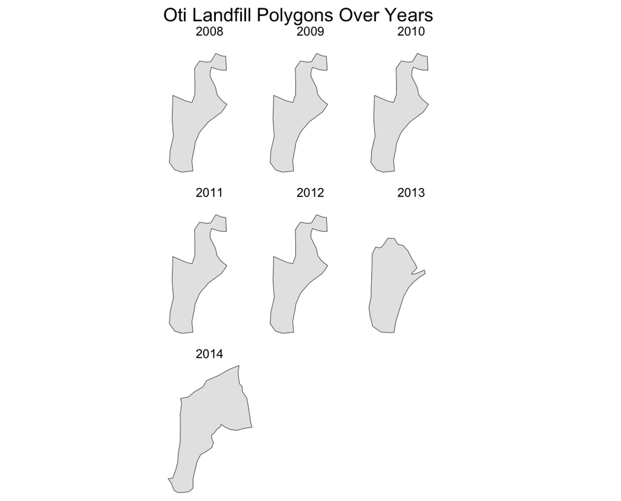

The change in Oti landfill growth throughout the years 2008 to 2014.

### Kenya

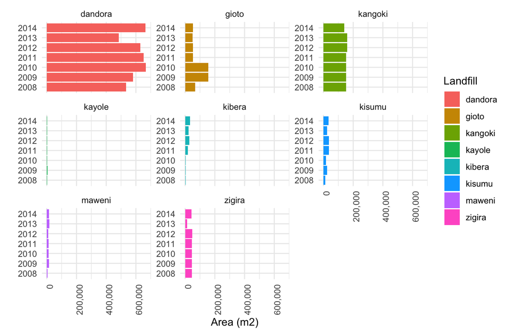

These show all the landfill areas derived from the Kenya polygons. The biggest landfill is Dandora located in the capital city of Nairobi.

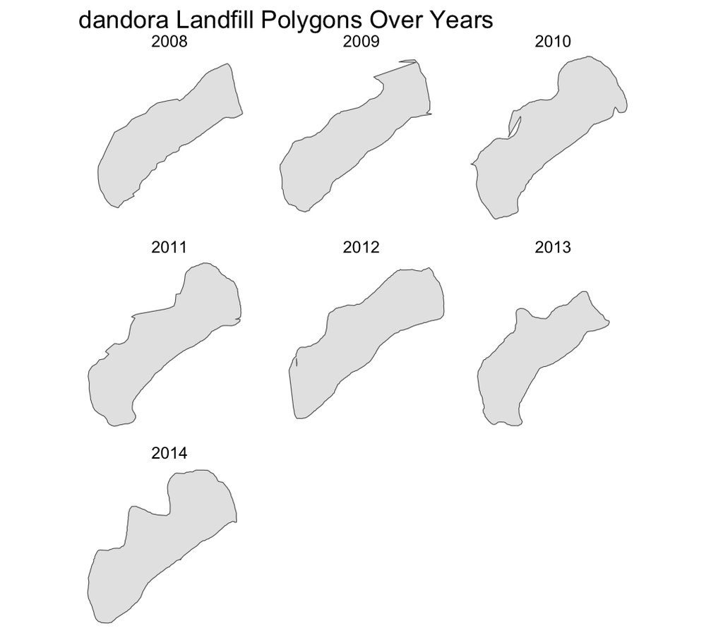

The change in Dandora landfill growth through the years.

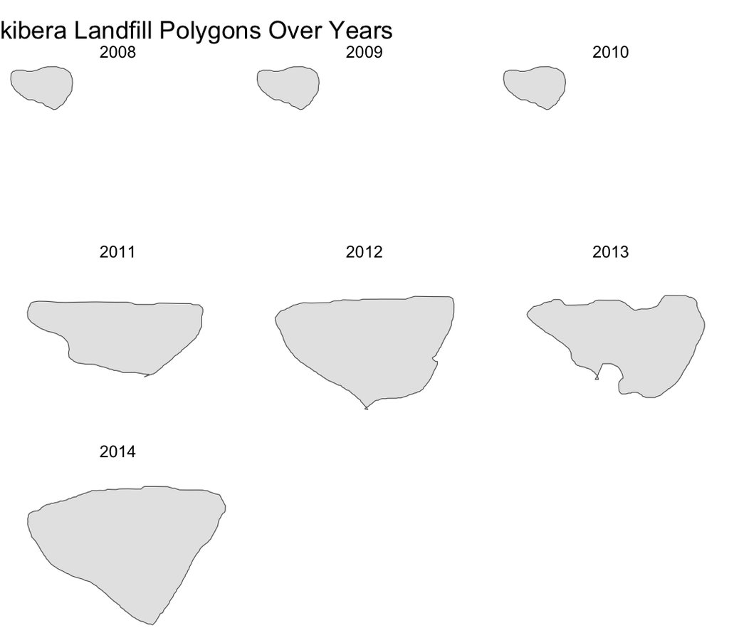

The change in Kibera landfill growth through the years.

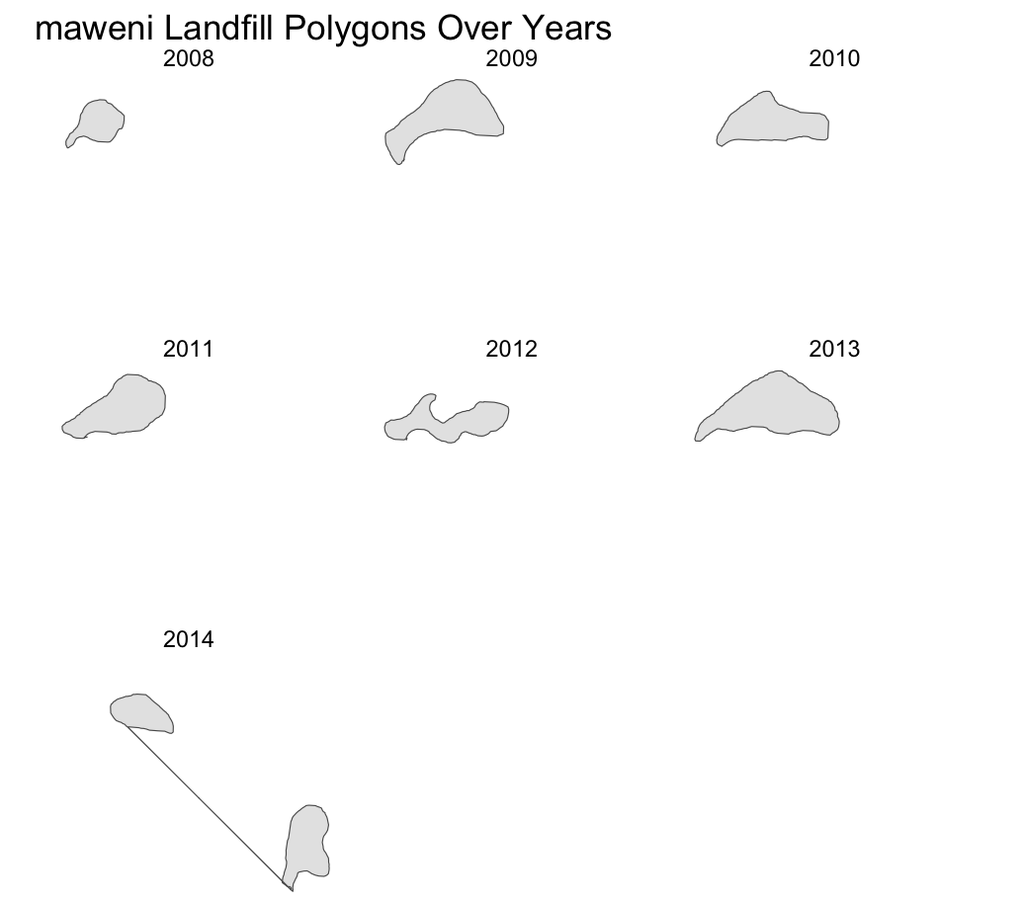

The change in Maweni landfill growth through the years.

## *Descriptive statistics*

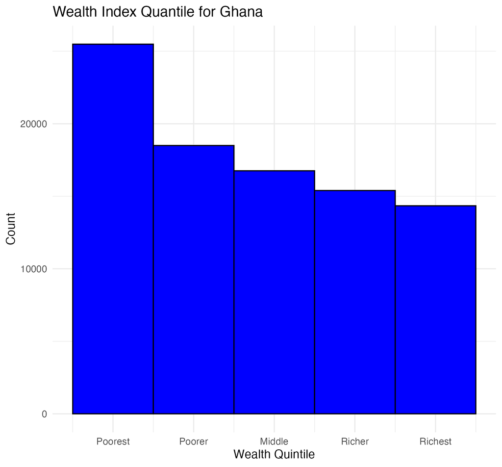

Histogram 1. This shows the average household wealth index in Ghana consisting of years 2008 and 2014. The majority of the households have a wealth index of 1: Poorest, while the least amount of households have a wealth index of 5: Richest.

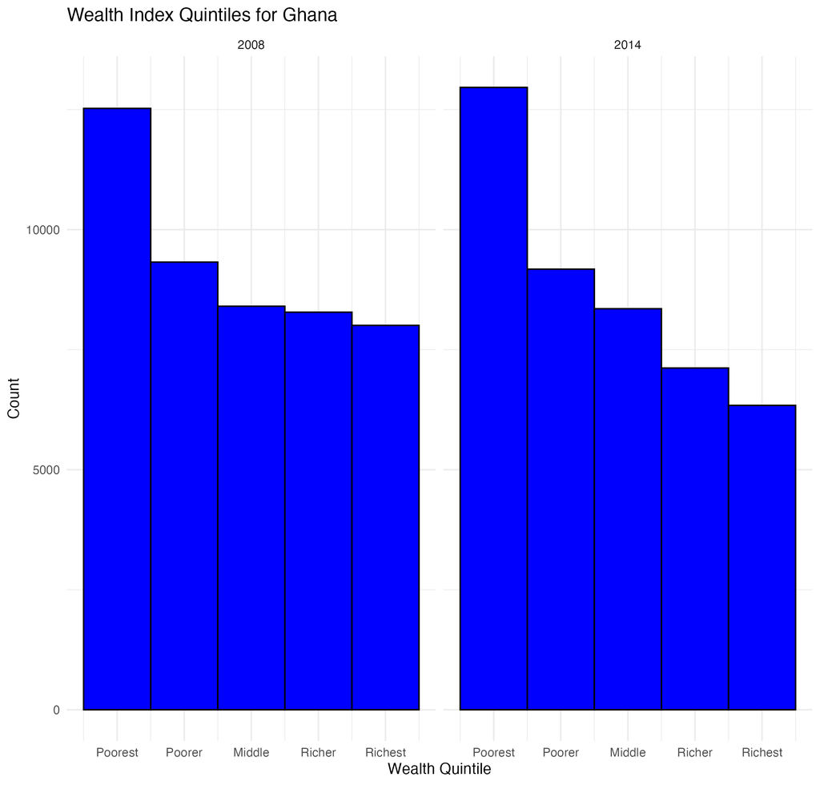

Histogram 2. This shows the household wealth index in Ghana for specifically year 2008 and 2014. Both follow similar trends, but we can see that in year 2014 the amount of households categorized as Poorest increase, while Richer and Richest decreased compared to the previous year.

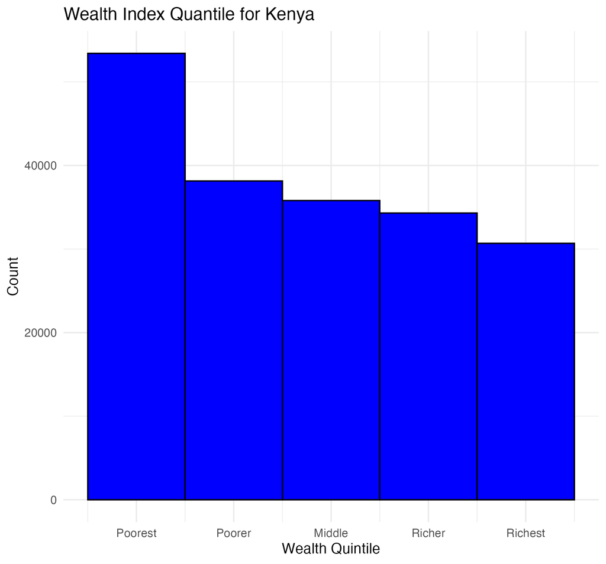

Histogram 3. This shows the average household wealth index for Kenya.

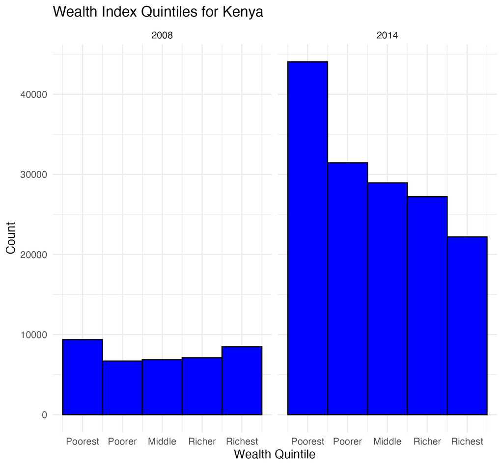

Histogram 4. This shows the household wealth index for Kenya for the year 2008 and 2014. The result in 2008 shows could be considered insignificant due to the low amount of household data available. It shows a relative same count for 1:Poorest and 5: Richest. For the year 2014, the results are more consistent with Ghana. However, it is important to note that the household count in Kenya for year 2014 is significantly larger than Ghana’s count.

## Preliminary Results

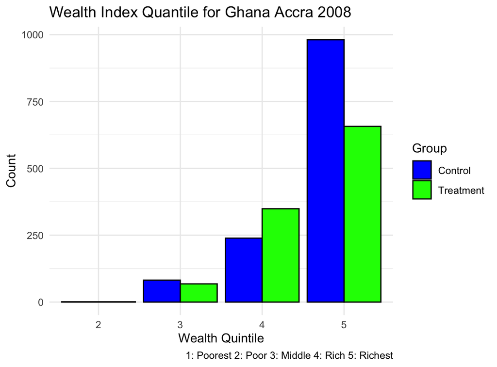

Histogram 5. Wealth index quantile for Ghana, Agbogbloshie landfill. Both treatment and control groups have the most number of households within wealth index 5: Richest, however the control group has a higher count compared to the treatment.

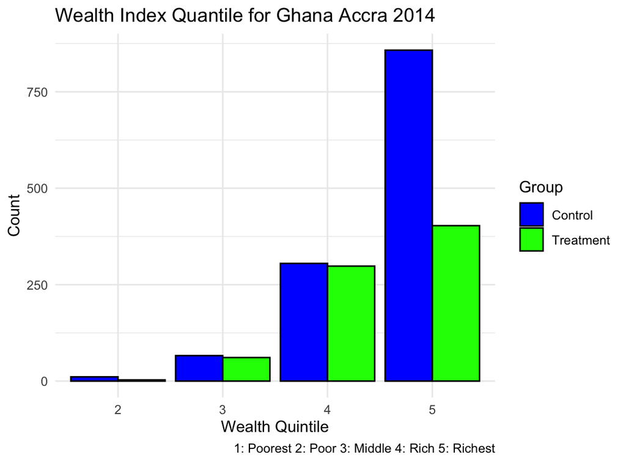

Histogram 6. Wealth index quantile for Ghana, Agbogbloshie landfill. Control group has the most number of households within the wealth index 5: Richest. While the treatment group has a much lower count, and is more evenly distributed between 4: Richer and 5: Richest.

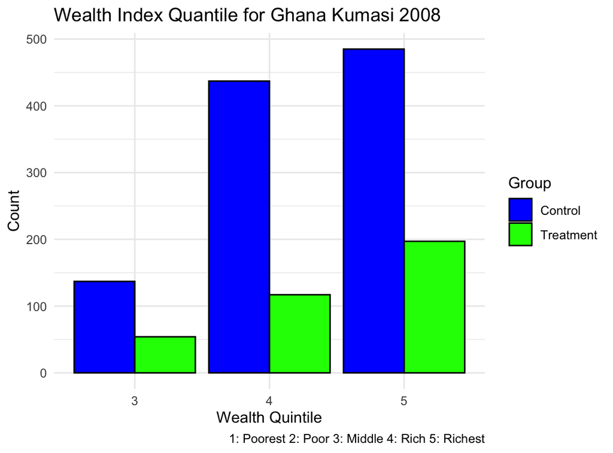

Histogram 7. Wealth index quantile for Ghana, Oti landfill. It is evident that the control group has the most households within the wealth index of 4. and 5. Whilst the treatment group has a lower count overall.

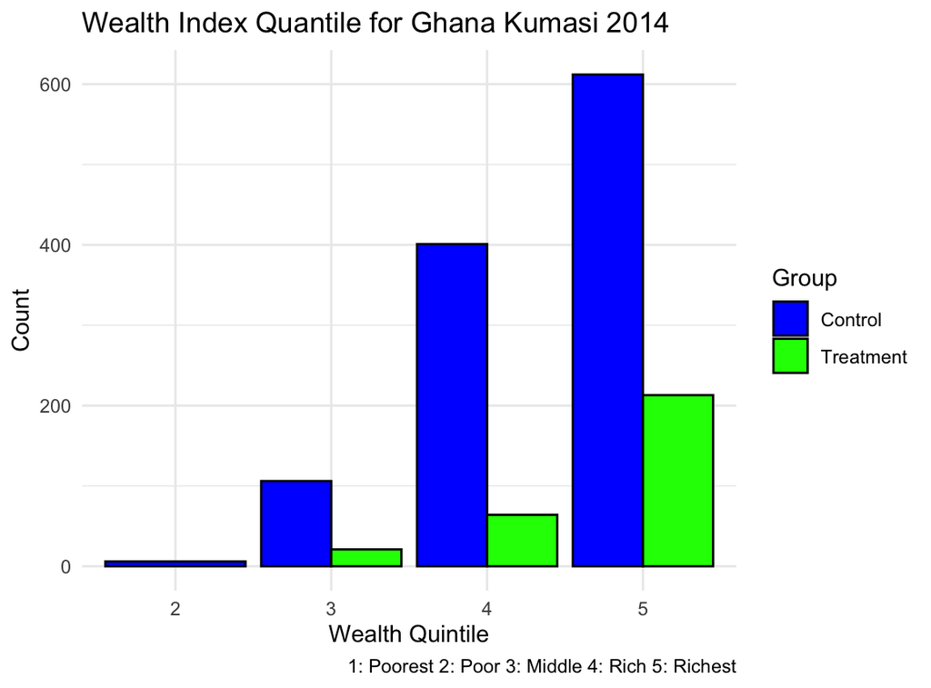

Histogram 8. Wealth index quantile for Ghana, Oti landfill. The control group has a higher count within the household index 5 and is the only group within household index 2: Poor.

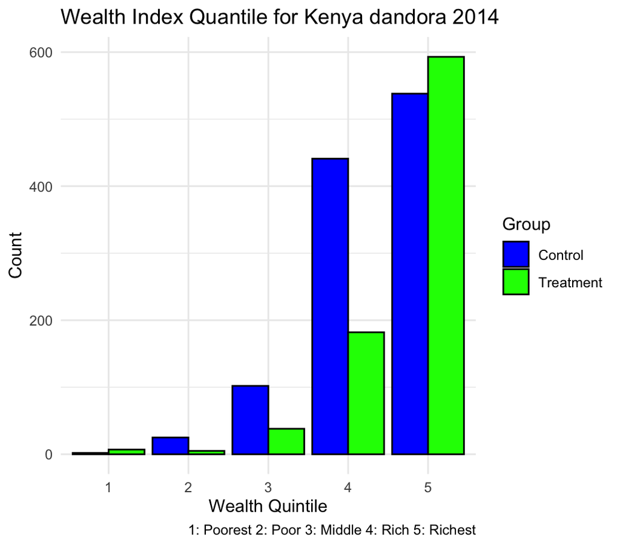

Histogram 9. Wealth index quantile for Kenya, Dandora landfill. Control group is mostly within the wealth index of 4: Richer and 5: Richest. However, the treatment group has the highest amount of households within the wealth quantile 5.

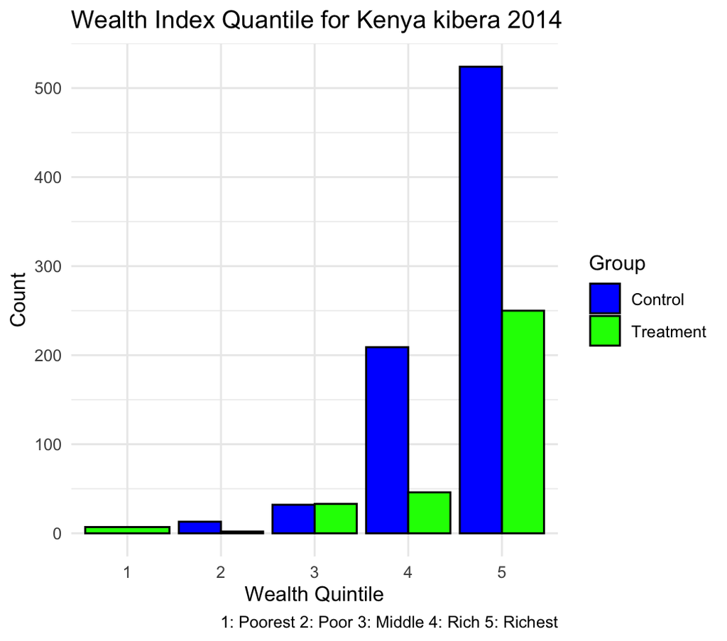

Histogram 10. Wealth index for Kenya, Kibera landfill. Control group is mostly situated in wealth index 5: Richest. The treatment group holds the only count within wealth index 1: Poorest.

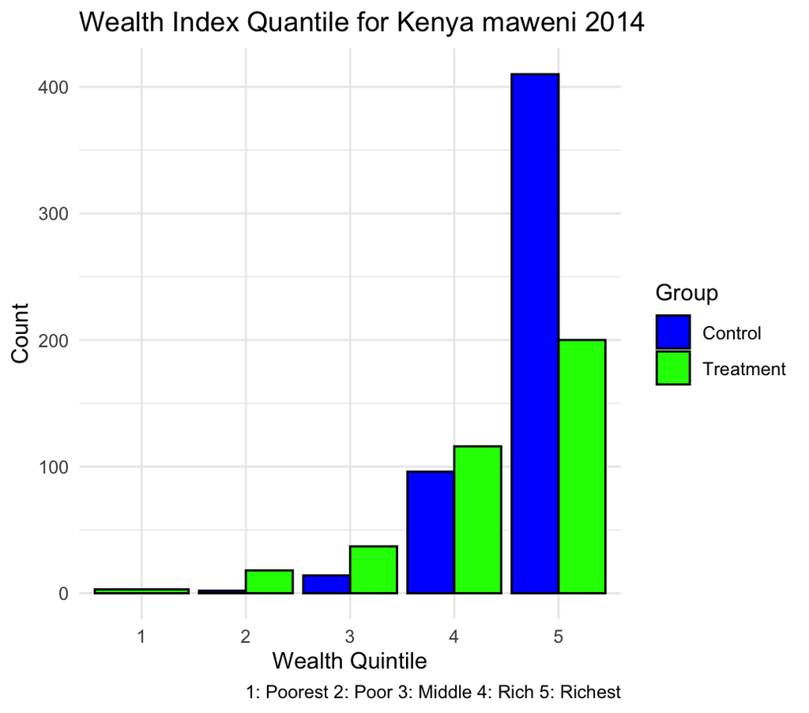

Histogram 11. Wealth index quantile for Kenya, Maweni landfill. There is a strong difference between count of control and treatment group within wealth index 5: Richest.

# Packages

(Hester and Csárdi 2024; Wickham, Miller, and Smith 2023; Wickham et al. 2019, 2023; Wickham, Vaughan, and Girlich 2024; Wickham 2016; Müller 2020; Giraud 2024; Pebesma and Bivand 2023; Zhu 2024; Iannone et al. 2024; Sjoberg et al. 2021; Fabri 2020; Wickham, Hester, and Bryan 2024; Pebesma, Mailund, and Hiebert 2016; Dunnington 2023; Xie 2024; Dunnington and Pebesma 2023; Wickham, Pedersen, and Seidel 2023)

## References

Dunnington, Dewey. 2023. “Ggspatial: Spatial Data Framework for Ggplot2.” https://CRAN.R-project.org/package=ggspatial.

Dunnington, Dewey, and Edzer Pebesma. 2023. “Geos: Open Source Geometry Engine (’GEOS’) r API.” https://CRAN.R-project.org/package=geos.

“Earth Versions.” n.d. *Google Earth*. Accessed June 23, 2024. https://www.google.com/earth/versions/.

Fabri, Antoine. 2020. “Unglue: Extract Matched Substrings Using a Pattern.” https://CRAN.R-project.org/package=unglue.

Giraud, Timothée. 2024. “Maptiles: Download and Display Map Tiles.” https://CRAN.R-project.org/package=maptiles.

Hester, Jim, and Gábor Csárdi. 2024. “Archive: Multi-Format Archive and Compression Support.” https://CRAN.R-project.org/package=archive.

Iannone, Richard, Joe Cheng, Barret Schloerke, Ellis Hughes, Alexandra Lauer, and JooYoung Seo. 2024. “Gt: Easily Create Presentation-Ready Display Tables.” https://CRAN.R-project.org/package=gt.

“IPUMS-DHS.” n.d. Accessed June 23, 2024. https://www.idhsdata.org/idhs/.

Müller, Kirill. 2020. “Here: A Simpler Way to Find Your Files.” https://CRAN.R-project.org/package=here.

Pebesma, Edzer, and Roger Bivand. 2023. “Spatial Data Science: With Applications in r.” https://doi.org/10.1201/9780429459016.

Pebesma, Edzer, Thomas Mailund, and James Hiebert. 2016. “Measurement Units in r” 8. https://doi.org/10.32614/RJ-2016-061.

Sjoberg, Daniel D., Karissa Whiting, Michael Curry, Jessica A. Lavery, and Joseph Larmarange. 2021. “Reproducible Summary Tables with the Gtsummary Package” 13: 570–80. https://doi.org/10.32614/RJ-2021-053.

Wickham, Hadley. 2016. “Ggplot2: Elegant Graphics for Data Analysis.” https://ggplot2.tidyverse.org.

Wickham, Hadley, Mara Averick, Jennifer Bryan, Winston Chang, Lucy D’Agostino McGowan, Romain François, Garrett Grolemund, et al. 2019. “Welcome to the Tidyverse” 4: 1686. https://doi.org/10.21105/joss.01686.

Wickham, Hadley, Romain François, Lionel Henry, Kirill Müller, and Davis Vaughan. 2023. “Dplyr: A Grammar of Data Manipulation.” https://CRAN.R-project.org/package=dplyr.

Wickham, Hadley, Jim Hester, and Jennifer Bryan. 2024. “Readr: Read Rectangular Text Data.” https://CRAN.R-project.org/package=readr.

Wickham, Hadley, Evan Miller, and Danny Smith. 2023. “Haven: Import and Export ’SPSS’, ’Stata’ and ’SAS’ Files.” https://CRAN.R-project.org/package=haven.

Wickham, Hadley, Thomas Lin Pedersen, and Dana Seidel. 2023. “Scales: Scale Functions for Visualization.” https://CRAN.R-project.org/package=scales.

Wickham, Hadley, Davis Vaughan, and Maximilian Girlich. 2024. “Tidyr: Tidy Messy Data.” https://CRAN.R-project.org/package=tidyr.

Xie, Yihui. 2024. “Knitr: A General-Purpose Package for Dynamic Report Generation in r.” https://yihui.org/knitr/.

Zhu, Hao. 2024. “kableExtra: Construct Complex Table with ’Kable’ and Pipe Syntax.” https://CRAN.R-project.org/package=kableExtra.